# Module 05 — Full-text retrieval, and what failing to retrieve tells us

HWC North Africa automated evidence map

2026-08-23

```r
knitr::opts_chunk$set(echo = TRUE, warning = TRUE, message = TRUE, dpi = 300)
suppressPackageStartupMessages({
  library(here); library(dplyr); library(tibble); library(readr); library(ggplot2)
})
source(here::here("R", "config.R"))
```

# 1 What this module does, and why the failures are the result

Module 04b returned 550 included records. This module tries to obtain the full text of each one: resolve an open-access PDF, download it, push it through GROBID to get TEI XML, and check whether the TEI carries recognisable methods and results sections. Records whose PDF is a scan rather than digital text would go to OCR.

The obvious way to report this module is a single success rate. That would waste it. **Which papers we can and cannot read is not a technical footnote; it is a measurement of access inequality that bears directly on what this evidence map can see.** If full text is systematically harder to obtain for one country’s literature, then any finding that rests on full-text fields is biased against that country, and the bias has a direction we can state. So everything below is broken down by country, by language and by source.

```r
ret   <- readRDS(here::here(DIR_DERIVED, "retrieval_ledger.rds"))
tiers <- readRDS(here::here(DIR_DERIVED, "geography_tiers.rds"))
n_att <- NROW(ret)
n_dl  <- sum(ret$downloaded %in% TRUE)
n_tei <- sum(ret$tei_ok %in% TRUE)
n_met <- sum(ret$has_methods %in% TRUE)
```

# 2 The retrieval cascade

Every stage prints what it lost.

```r
cascade <- tibble::tibble(
  stage = c("records entering Module 05",
            "candidate PDF URL resolved",
            "PDF downloaded",
            "GROBID produced parseable TEI",
            "TEI carries methods/results heads"),
  n = c(n_att,
        sum(!is.na(ret$url)),
        n_dl,
        n_tei,
        n_met)) |>
  dplyr::mutate(lost = dplyr::lag(n) - n,
                pct_of_entering = round(100 * n / n_att, 1))
knitr::kable(cascade, caption = "Full-text retrieval cascade, with losses at each stage")
```

Full-text retrieval cascade, with losses at each stage

| stage | n | lost | pct_of_entering |
| --- | --- | --- | --- |
| records entering Module 05 | 550 | NA | 100.0 |
| candidate PDF URL resolved | 349 | 201 | 63.5 |
| PDF downloaded | 286 | 63 | 52.0 |
| GROBID produced parseable TEI | 286 | 0 | 52.0 |
| TEI carries methods/results heads | 228 | 58 | 41.5 |

Of 550 records, 286 yielded a downloadable PDF (52.0%) and 286 produced parseable TEI (52.0%). The gap between those two numbers is small, so GROBID is not the bottleneck: **acquisition is.**

```r
n_scan <- sum(ret$is_scanned %in% TRUE)
n_ocr  <- sum(ret$ocr_applied %in% TRUE)
```

0 of the downloaded PDFs were scans (near-zero extractable characters per page), so OCR fired on 0. The OCR path (`ocrmac` first, `tesseract` with `fra`/`ara` as fallback) is implemented and was smoke-tested, but this corpus never exercised it. That is itself worth stating: the open-access material we could reach is uniformly born-digital, which is a property of *what is reachable*, not of the regional literature. Scanned regional reports and theses are exactly the material sitting behind the failures tabulated below.

# 3 Why retrieval failed

```r
fails <- ret |>
  dplyr::filter(!(tei_ok %in% TRUE)) |>
  dplyr::count(failure_reason, sort = TRUE) |>
  dplyr::mutate(pct_of_failures = round(100 * n / sum(n), 1))
knitr::kable(fails, caption = "Reason for failure, over records that did not reach TEI")
```

Reason for failure, over records that did not reach TEI

| failure_reason | n | pct_of_failures |
| --- | --- | --- |
| no_pdf_url | 63 | 23.9 |
| http_403 | 61 | 23.1 |
| publisher_blocked | 59 | 22.3 |
| network_error | 27 | 10.2 |
| landing_page_not_pdf | 22 | 8.3 |
| http_401 | 9 | 3.4 |
| http_429 | 8 | 3.0 |
| http_202 | 7 | 2.7 |
| http_404 | 5 | 1.9 |
| not_a_pdf | 2 | 0.8 |
| empty_response | 1 | 0.4 |

```r
paywall <- fails |>
  dplyr::filter(failure_reason %in% c("http_403", "publisher_blocked",
                                      "http_401", "landing_page_not_pdf")) |>
  dplyr::pull(n) |> sum()
no_url  <- fails |> dplyr::filter(failure_reason == "no_pdf_url") |> dplyr::pull(n) |> sum()
transient <- fails |>
  dplyr::filter(failure_reason %in% c("network_error", "http_429", "http_202",
                                      "empty_response")) |>
  dplyr::pull(n) |> sum()
```

These group into three kinds, and they mean different things:

- **151 records were refused by a publisher** (403, 401, an interstitial landing page, or a known blocking host). The paper exists and is indexed; we are not permitted to read it.
- **63 records had no open-access PDF location at all** in OpenAlex or CORE. Not refused — simply not deposited anywhere reachable.
- **43 failures were transient** (network, rate limiting, 202 “still processing”). These are the only ones a re-run could plausibly recover, and they are a small minority.

The first two categories are structural. **214 of 550 records — 38.9% — are unreadable for reasons of access, not of technique.**

# 4 Access inequality by country

```r
by_country <- ret |>
  dplyr::group_by(country) |>
  dplyr::summarise(
    n          = dplyr::n(),
    downloaded = sum(downloaded %in% TRUE),
    tei        = sum(tei_ok %in% TRUE),
    tei_pct    = round(100 * sum(tei_ok %in% TRUE) / dplyr::n(), 1),
    .groups = "drop") |>
  dplyr::arrange(dplyr::desc(n))
knitr::kable(by_country,
             caption = "Full-text retrieval by search cell country (cell of origin, not verified study location)")
```

Full-text retrieval by search cell country (cell of origin, not verified study location)

| country | n | downloaded | tei | tei_pct |
| --- | --- | --- | --- | --- |
| EG | 187 | 97 | 97 | 51.9 |
| TN | 137 | 70 | 70 | 51.1 |
| MA | 90 | 46 | 46 | 51.1 |
| REGION | 64 | 35 | 35 | 54.7 |
| DZ | 50 | 29 | 29 | 58.0 |
| LY | 22 | 9 | 9 | 40.9 |

```r
best     <- by_country |> dplyr::slice_max(tei_pct, n = 1)
worst    <- by_country |> dplyr::slice_min(tei_pct, n = 1)
thinnest <- by_country |> dplyr::slice_min(n, n = 1)
compounds <- identical(worst$country, thinnest$country)
```

The spread runs from 40.9% (LY, n = 22) to 58.0% (DZ, n = 50).

**The thinnest cell is also the hardest to read.** LY returns the fewest records (n = 22) *and* the lowest full-text rate (40.9%), so the two shortfalls compound. Any LY count in Module 07 is doubly attenuated, and a low count there must not be presented as a measured absence of research.

A caution on this table. `country` here is the **search cell** a record was retrieved from, not where the study was actually conducted — Module 06 stage 0 showed those diverge badly. The table is the right one for judging *retrieval* (the cell is what drove which publishers we hit), but it must not be read as studies-per-country.

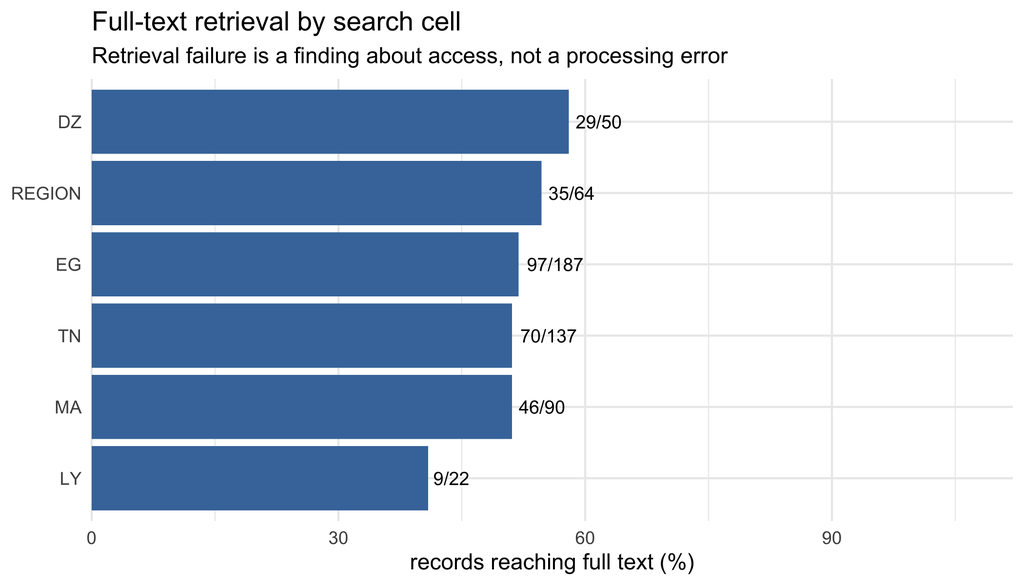

```r
p <- ggplot(by_country, aes(x = reorder(country, tei_pct), y = tei_pct)) +
  geom_col(fill = "#4477AA") +
  geom_text(aes(label = sprintf("%d/%d", tei, n)), hjust = -0.15, size = 3.2) +
  coord_flip(clip = "off") +
  scale_y_continuous(limits = c(0, 100), expand = expansion(mult = c(0, 0.12))) +
  labs(x = NULL, y = "records reaching full text (%)",
       title = "Full-text retrieval by search cell",
       subtitle = "Retrieval failure is a finding about access, not a processing error") +
  theme_minimal(base_size = 11)
print(p)
```

```r
dir.create(here::here(DIR_FIGURES), showWarnings = FALSE, recursive = TRUE)
ggsave(here::here(DIR_FIGURES, "05_retrieval_by_country.png"), p,
       width = 7, height = 4, dpi = 300)
ggsave(here::here(DIR_FIGURES, "05_retrieval_by_country.svg"), p,
       width = 7, height = 4)
```

# 5 Access inequality by openness and source

```r
by_oa <- ret |>
  dplyr::group_by(is_oa = dplyr::coalesce(is_oa, NA)) |>
  dplyr::summarise(n = dplyr::n(), tei = sum(tei_ok %in% TRUE),
                   tei_pct = round(100 * sum(tei_ok %in% TRUE) / dplyr::n(), 1),
                   .groups = "drop")
knitr::kable(by_oa, caption = "Retrieval by OpenAlex open-access flag")
```

Retrieval by OpenAlex open-access flag

| is_oa | n | tei | tei_pct |
| --- | --- | --- | --- |
| FALSE | 31 | 2 | 6.5 |
| TRUE | 519 | 284 | 54.7 |

```r
by_source <- ret |>
  dplyr::group_by(source) |>
  dplyr::summarise(n = dplyr::n(), tei = sum(tei_ok %in% TRUE),
                   tei_pct = round(100 * sum(tei_ok %in% TRUE) / dplyr::n(), 1),
                   .groups = "drop") |>
  dplyr::arrange(dplyr::desc(n))
knitr::kable(by_source, caption = "Retrieval by discovery source")
```

Retrieval by discovery source

| source | n | tei | tei_pct |
| --- | --- | --- | --- |
| openalex | 532 | 277 | 52.1 |
| core | 18 | 9 | 50.0 |

# 6 What this leaves the evidence map to work with

```r
an <- tiers |>
  dplyr::filter(analytic) |>
  dplyr::left_join(ret |> dplyr::select(id, tei_ok, has_methods), by = "id")
n_an     <- NROW(an)
n_an_tei <- sum(an$tei_ok %in% TRUE)
```

Module 06 stage 0 reduced the 550 included records to an analytic set of 262 records actually situated in the five countries. Of those, 121 (46.2%) have full text.

```r
knitr::kable(
  an |> dplyr::group_by(tier) |>
    dplyr::summarise(n = dplyr::n(), with_full_text = sum(tei_ok %in% TRUE),
                     pct = round(100 * sum(tei_ok %in% TRUE) / dplyr::n(), 1),
                     .groups = "drop"),
  caption = "Full-text coverage within the analytic set, by geographic confidence tier")
```

Full-text coverage within the analytic set, by geographic confidence tier

| tier | n | with_full_text | pct |
| --- | --- | --- | --- |
| A_named_country_corroborated | 79 | 31 | 39.2 |
| B_regional_corroborated | 106 | 46 | 43.4 |
| C_asserted_no_evidence | 77 | 44 | 57.1 |

This is the number that shapes Module 06. Extracting only from full text would silently redefine the map as a map of the open-access subset — and this module has just shown that subset is not drawn evenly. So Module 06 extracts every analytic record, from TEI methods/results where available and from title and abstract otherwise, carries an `evidence_base` flag on every value, and stratifies every reliability figure by it. Fields that only full text can support are reported over the full-text stratum alone, with that denominator printed.

# 7 Method parameters for the supplement

| parameter | value |
| --- | --- |
| PDF sources, in priority order | pdf_url captured at search time; OpenAlex best_oa_location; CORE by DOI |
| TEI extraction | GROBID processFulltextDocument |
| Scanned-page test | median extractable characters per page near zero |
| OCR engines (unused this run) | ocrmac, tesseract, paddleocr |
| Download timeout | 120 s |
| GROBID timeout | 300 s |